# Tornado Events are Most Harmful to Population Health and Economy

Denis Levert

September 11, 2020

## Synopsis

The intent of this analysis is to obtain the data from NOAA’s National Weather Center’s website. Then to process the data into a usable format. The data has been analyzed from two perspectives;

1. The event with the largest impact on peoples health.
2. The event with the largest impact on economy.

the data clearly indicates that tornadoes have the largest impact on on both health and economy.

## Data Processing

```r
# FUNCTION TO IMPORT DATA AND FORMAT CERTAIN VARIABLES====================
     require(lubridate)
     wd <- read.csv("repdata-data-StormData.csv.bz2")
#FORMAT DATE
     wd$BGN_DATE <- sub(" .*", "", wd$BGN_DATE)
     wd$BGN_DATE <- mdy(wd$BGN_DATE)
#FORMAT TIME
     d <- paste(wd$BGN_DATE,wd$BGN_TIME, wd$TIME_ZONE)
     d <- parse_date_time(d,"%Y-%m-%d %H:%M:%S",
                          truncated = TRUE)
     wd$BGN_TIME <- d
#FORMAT FACTORS
     wd$COUNTYNAME <- as.factor(wd$COUNTYNAME)
     wd$STATE <- as.factor(wd$STATE)
     wd$EVTYPE <- as.factor(wd$EVTYPE)
     wd <<- wd
```

## Results

### Which type of events are most harmful with respect to health?

The following code is meant to summarize the data by injuries and deaths, then add them together for a total amount of injuries indicating the effect on peoples health.

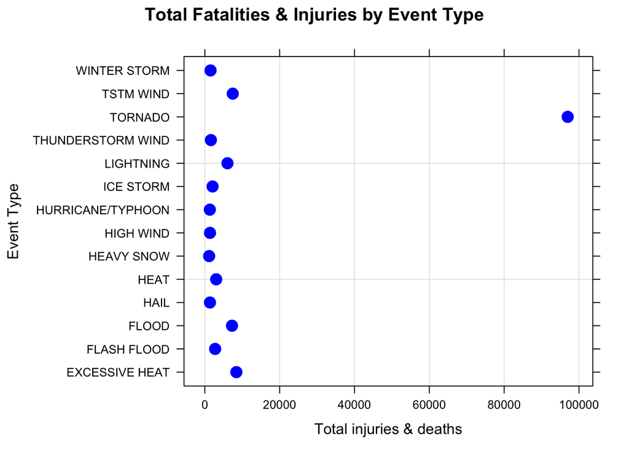

```r
        require(dplyr)
        require(lattice)
# SUBSET DATA FOR PLOT
        sub <- wd %>% group_by(EVTYPE) %>%
                summarise(fatal = sum(FATALITIES),
                          inj = sum(INJURIES),
                          totinj = sum(FATALITIES) + sum(INJURIES))
        sub <- filter(sub, fatal > 1000 | inj > 1000)
        sub <- arrange(sub, desc(fatal), desc(inj))
# OBTAIN STATS
        a <- max(sub$totinj)
        a <- subset(sub, sub$totinj == a)
        a <- paste("The most harmful event type is", a$EVTYPE , " with",
                   a$fatal , "fatalities and,", a$inj, "injuries")
# PLOT RESULTS
        xyplot(sub$EVTYPE ~ sub$totinj, sub,
               col = c("blue"), pch = 19, cex = 1.5, grid = TRUE,
               main = "Total Fatalities & Injuries by Event Type",
               xlab = "Total injuries & deaths",
               ylab = "Event Type")
```

```r
        print(a)
```

```
## [1] "The most harmful event type is TORNADO  with 5633 fatalities and, 91346 injuries"
```

The graph clearly shows that Tornados cause the most injuries to Americans than any other type of weather event.

## Which type of events have the greatest economic consequences?

The following code will subset the data and total the economic impact of events. It will chart the total by event type. The chart clearly indicates that tornadoes have the largest impact on ecomincs.

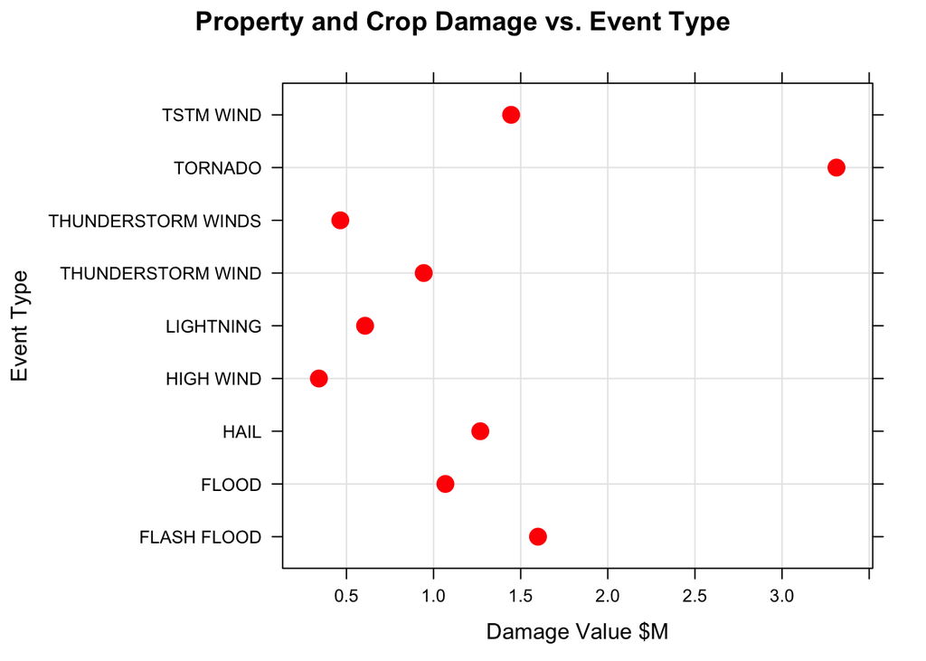

```r
# SUBSET DATA FOR PLOT
        require(dplyr)
        require(lattice)
        sub2 <- wd %>% group_by(EVTYPE) %>%
                summarise(pd = sum(PROPDMG), cd = sum(CROPDMG),
                          td = sum(PROPDMG)+sum(CROPDMG))
        sub2 <- filter(sub2,td > 250000)
# OBTAIN STATS
        b <- max(sub2$td)
        b <- subset(sub2, sub2$td == b)
        b <- paste("The most economic impactful weather event is ", b$EVTYPE,
                          " with a property damage of $",
                   format(b$pd, nsmall = 0, big.mark = ","),
                   " a crop damage of $",
                   format(b$cd, nsmall = 0, big.mark = ","),
                   " and a total of $",
                   format(b$td, nsmall = 0, big.mark = ","), sep = "")
# PLOT RESULTS
        xyplot(sub2$EVTYPE ~ sub2$td/1000000, sub2,
               grid = TRUE, pch = 19, cex = 1.5, col = "red",
               main = "Property and Crop Damage vs. Event Type",
               xlab = "Damage Value $M",
               ylab = "Event Type")
```

```r
        print(b)
```

```
## [1] "The most economic impactful weather event is TORNADO with a property damage of $3,212,258 a crop damage of $100,018.5 and a total of $3,312,277"
```

Tornadoes have the largest financial impact compared to other weather events.